# Risk Factor Analysis

## Outcome Variable

**Outcome Variable:** swasted

## Predictor Variables

**Intervention Variable:** predfeed36

**Adjustment Set:**

- arm
- sex
- month
- brthmon
- W_mage
- meducyrs
- feducyrs
- hhwealth_quart
- hfoodsec
- W_mhtcm
- W_mwtkg
- W_mbmi
- vagbrth
- W_gagebrth
- W_birthwt
- W_birthlen
- W_nrooms
- W_nchldlt5
- W_parity
- impfloor
- impsan
- safeh20
- delta_W_mage
- delta_meducyrs
- delta_feducyrs
- delta_hhwealth_quart
- delta_hfoodsec
- delta_W_mhtcm
- delta_W_mwtkg
- delta_W_mbmi
- delta_vagbrth
- delta_W_gagebrth
- delta_W_birthwt
- delta_W_birthlen
- delta_W_nrooms
- delta_W_nchldlt5
- delta_W_parity
- delta_impfloor
- delta_impsan
- delta_safeh20

## Stratifying Variables

The analysis was stratified on these variable(s):

- agecat
- studyid
- country

## Data Summary

| agecat | studyid | country | predfeed36 | swasted | n_cell | n |
| --- | --- | --- | --- | --- | --- | --- |
| Birth | EE | PAKISTAN | 1 | 0 | 2 | 6 |
| Birth | EE | PAKISTAN | 1 | 1 | 0 | 6 |
| Birth | EE | PAKISTAN | 0 | 0 | 3 | 6 |
| Birth | EE | PAKISTAN | 0 | 1 | 1 | 6 |
| Birth | GMS-Nepal | NEPAL | 1 | 0 | 378 | 491 |
| Birth | GMS-Nepal | NEPAL | 1 | 1 | 18 | 491 |
| Birth | GMS-Nepal | NEPAL | 0 | 0 | 92 | 491 |
| Birth | GMS-Nepal | NEPAL | 0 | 1 | 3 | 491 |
| Birth | JiVitA-3 | BANGLADESH | 1 | 0 | 6603 | 8619 |
| Birth | JiVitA-3 | BANGLADESH | 1 | 1 | 143 | 8619 |
| Birth | JiVitA-3 | BANGLADESH | 0 | 0 | 1844 | 8619 |
| Birth | JiVitA-3 | BANGLADESH | 0 | 1 | 29 | 8619 |
| Birth | JiVitA-4 | BANGLADESH | 1 | 0 | 1695 | 2128 |
| Birth | JiVitA-4 | BANGLADESH | 1 | 1 | 19 | 2128 |
| Birth | JiVitA-4 | BANGLADESH | 0 | 0 | 404 | 2128 |
| Birth | JiVitA-4 | BANGLADESH | 0 | 1 | 10 | 2128 |
| Birth | MAL-ED | BANGLADESH | 1 | 0 | 69 | 208 |
| Birth | MAL-ED | BANGLADESH | 1 | 1 | 0 | 208 |
| Birth | MAL-ED | BANGLADESH | 0 | 0 | 131 | 208 |
| Birth | MAL-ED | BANGLADESH | 0 | 1 | 8 | 208 |
| Birth | MAL-ED | BRAZIL | 1 | 0 | 7 | 62 |
| Birth | MAL-ED | BRAZIL | 1 | 1 | 0 | 62 |
| Birth | MAL-ED | BRAZIL | 0 | 0 | 55 | 62 |
| Birth | MAL-ED | BRAZIL | 0 | 1 | 0 | 62 |
| Birth | MAL-ED | INDIA | 1 | 0 | 4 | 40 |
| Birth | MAL-ED | INDIA | 1 | 1 | 0 | 40 |
| Birth | MAL-ED | INDIA | 0 | 0 | 36 | 40 |
| Birth | MAL-ED | INDIA | 0 | 1 | 0 | 40 |
| Birth | MAL-ED | NEPAL | 1 | 0 | 1 | 25 |
| Birth | MAL-ED | NEPAL | 1 | 1 | 0 | 25 |

[output cut: 114 more lines]

The following strata were considered:

- agecat: 24 months, studyid: EE, country: PAKISTAN
- agecat: 24 months, studyid: GMS-Nepal, country: NEPAL
- agecat: 24 months, studyid: JiVitA-3, country: BANGLADESH
- agecat: 24 months, studyid: JiVitA-4, country: BANGLADESH
- agecat: 24 months, studyid: LCNI-5, country: MALAWI
- agecat: 24 months, studyid: MAL-ED, country: BANGLADESH
- agecat: 24 months, studyid: MAL-ED, country: BRAZIL
- agecat: 24 months, studyid: MAL-ED, country: INDIA
- agecat: 24 months, studyid: MAL-ED, country: NEPAL
- agecat: 24 months, studyid: MAL-ED, country: PERU
- agecat: 24 months, studyid: MAL-ED, country: SOUTH AFRICA
- agecat: 24 months, studyid: MAL-ED, country: TANZANIA, UNITED REPUBLIC OF
- agecat: 6 months, studyid: EE, country: PAKISTAN
- agecat: 6 months, studyid: GMS-Nepal, country: NEPAL
- agecat: 6 months, studyid: JiVitA-3, country: BANGLADESH
- agecat: 6 months, studyid: JiVitA-4, country: BANGLADESH
- agecat: 6 months, studyid: LCNI-5, country: MALAWI
- agecat: 6 months, studyid: MAL-ED, country: BANGLADESH
- agecat: 6 months, studyid: MAL-ED, country: BRAZIL
- agecat: 6 months, studyid: MAL-ED, country: INDIA
- agecat: 6 months, studyid: MAL-ED, country: NEPAL
- agecat: 6 months, studyid: MAL-ED, country: PERU
- agecat: 6 months, studyid: MAL-ED, country: SOUTH AFRICA
- agecat: 6 months, studyid: MAL-ED, country: TANZANIA, UNITED REPUBLIC OF
- agecat: 6 months, studyid: SAS-FoodSuppl, country: INDIA
- agecat: Birth, studyid: EE, country: PAKISTAN
- agecat: Birth, studyid: GMS-Nepal, country: NEPAL
- agecat: Birth, studyid: JiVitA-3, country: BANGLADESH
- agecat: Birth, studyid: JiVitA-4, country: BANGLADESH
- agecat: Birth, studyid: MAL-ED, country: BANGLADESH
- agecat: Birth, studyid: MAL-ED, country: BRAZIL
- agecat: Birth, studyid: MAL-ED, country: INDIA
- agecat: Birth, studyid: MAL-ED, country: NEPAL
- agecat: Birth, studyid: MAL-ED, country: PERU
- agecat: Birth, studyid: MAL-ED, country: SOUTH AFRICA
- agecat: Birth, studyid: MAL-ED, country: TANZANIA, UNITED REPUBLIC OF

### Dropped Strata

Some strata were dropped due to rare outcomes:

- agecat: Birth, studyid: EE, country: PAKISTAN
- agecat: Birth, studyid: GMS-Nepal, country: NEPAL
- agecat: Birth, studyid: MAL-ED, country: BANGLADESH
- agecat: Birth, studyid: MAL-ED, country: BRAZIL
- agecat: Birth, studyid: MAL-ED, country: INDIA
- agecat: Birth, studyid: MAL-ED, country: NEPAL
- agecat: Birth, studyid: MAL-ED, country: PERU
- agecat: Birth, studyid: MAL-ED, country: SOUTH AFRICA
- agecat: Birth, studyid: MAL-ED, country: TANZANIA, UNITED REPUBLIC OF
- agecat: 6 months, studyid: EE, country: PAKISTAN
- agecat: 6 months, studyid: GMS-Nepal, country: NEPAL
- agecat: 6 months, studyid: LCNI-5, country: MALAWI
- agecat: 6 months, studyid: MAL-ED, country: BANGLADESH
- agecat: 6 months, studyid: MAL-ED, country: BRAZIL
- agecat: 6 months, studyid: MAL-ED, country: INDIA
- agecat: 6 months, studyid: MAL-ED, country: NEPAL
- agecat: 6 months, studyid: MAL-ED, country: PERU
- agecat: 6 months, studyid: MAL-ED, country: SOUTH AFRICA
- agecat: 6 months, studyid: MAL-ED, country: TANZANIA, UNITED REPUBLIC OF
- agecat: 6 months, studyid: SAS-FoodSuppl, country: INDIA
- agecat: 24 months, studyid: EE, country: PAKISTAN
- agecat: 24 months, studyid: LCNI-5, country: MALAWI
- agecat: 24 months, studyid: MAL-ED, country: BANGLADESH
- agecat: 24 months, studyid: MAL-ED, country: BRAZIL
- agecat: 24 months, studyid: MAL-ED, country: INDIA
- agecat: 24 months, studyid: MAL-ED, country: NEPAL
- agecat: 24 months, studyid: MAL-ED, country: PERU
- agecat: 24 months, studyid: MAL-ED, country: SOUTH AFRICA
- agecat: 24 months, studyid: MAL-ED, country: TANZANIA, UNITED REPUBLIC OF

## Methods Detail

We’re interested in the causal parameters $E[Y_a]$ for all values of $a \in \mathcal{A}$. These parameters represent the mean outcome if, possibly contrary to fact, we intervened to set all units to have $A=a$. Under the randomization and positivity assumptions, these are identified by the statistical parameters $\psi_a=E_W[E_{Y|A,W}(Y|A=a,W)]$. In addition, we’re interested in the mean of $Y$, $E[Y]$ under no intervention (the observed mean). We will estimate these parameters by using SuperLearner to fit the relevant likelihood factors – $E_{Y|A,W}(Y|A=a,W)$ and $p(A=a|W)$, and then updating our likelihood fit using a joint TMLE.

For unadjusted analyses ($W=\{\}$), initial likelihoods were estimated using Lrnr_glm to estimate the simple $E(Y|A)$ and Lrnr_mean to estimate $p(A)$. For adjusted analyses, a small library containing Lrnr_glmnet, Lrnr_xgboost, and Lrnr_mean was used.

Having estimated these parameters, we will then use the delta method to estimate relative risks and attributable risks relative to a prespecified baseline level of $A$.

# Results Detail

## Results Plots

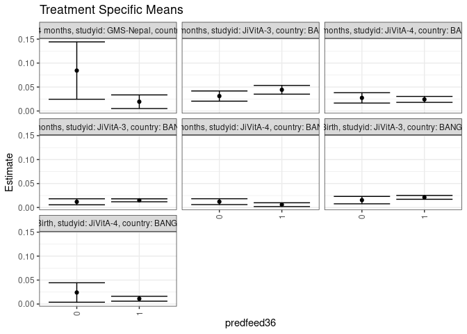

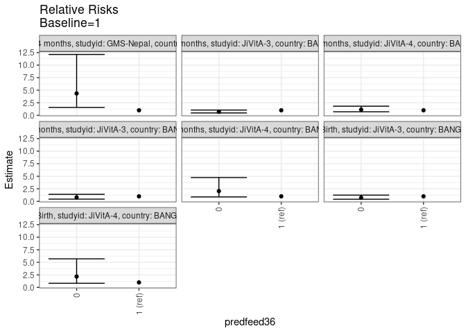

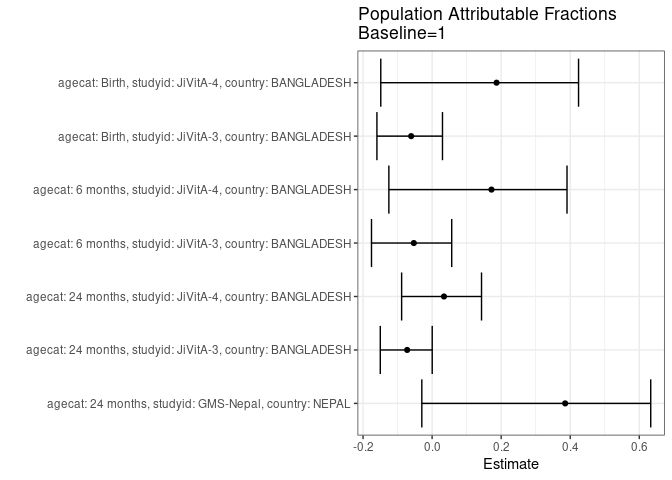

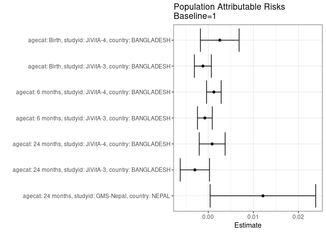

## Results Table

### Parameter: TSM

| agecat | studyid | country | intervention_level | baseline_level | estimate | ci_lower | ci_upper |
| --- | --- | --- | --- | --- | --- | --- | --- |
| Birth | JiVitA-3 | BANGLADESH | 1 | NA | 0.0211668 | 0.0171509 | 0.0251826 |
| Birth | JiVitA-3 | BANGLADESH | 0 | NA | 0.0154254 | 0.0077179 | 0.0231329 |
| Birth | JiVitA-4 | BANGLADESH | 1 | NA | 0.0110842 | 0.0059808 | 0.0161875 |
| Birth | JiVitA-4 | BANGLADESH | 0 | NA | 0.0240736 | 0.0037511 | 0.0443960 |
| 6 months | JiVitA-3 | BANGLADESH | 1 | NA | 0.0150519 | 0.0119842 | 0.0181197 |
| 6 months | JiVitA-3 | BANGLADESH | 0 | NA | 0.0119117 | 0.0056328 | 0.0181905 |
| 6 months | JiVitA-4 | BANGLADESH | 1 | NA | 0.0059315 | 0.0019719 | 0.0098912 |
| 6 months | JiVitA-4 | BANGLADESH | 0 | NA | 0.0121520 | 0.0060367 | 0.0182673 |
| 24 months | GMS-Nepal | NEPAL | 1 | NA | 0.0193370 | 0.0051354 | 0.0335386 |
| 24 months | GMS-Nepal | NEPAL | 0 | NA | 0.0843373 | 0.0244858 | 0.1441889 |
| 24 months | JiVitA-3 | BANGLADESH | 1 | NA | 0.0442125 | 0.0350955 | 0.0533296 |
| 24 months | JiVitA-3 | BANGLADESH | 0 | NA | 0.0311075 | 0.0204517 | 0.0417634 |
| 24 months | JiVitA-4 | BANGLADESH | 1 | NA | 0.0241723 | 0.0179848 | 0.0303598 |
| 24 months | JiVitA-4 | BANGLADESH | 0 | NA | 0.0273331 | 0.0165707 | 0.0380955 |

### Parameter: E(Y)

| agecat | studyid | country | intervention_level | baseline_level | estimate | ci_lower | ci_upper |
| --- | --- | --- | --- | --- | --- | --- | --- |
| Birth | JiVitA-3 | BANGLADESH | NA | NA | 0.0199559 | 0.0164404 | 0.0234714 |
| Birth | JiVitA-4 | BANGLADESH | NA | NA | 0.0136278 | 0.0077812 | 0.0194744 |
| 6 months | JiVitA-3 | BANGLADESH | NA | NA | 0.0142941 | 0.0115468 | 0.0170414 |
| 6 months | JiVitA-4 | BANGLADESH | NA | NA | 0.0071633 | 0.0038384 | 0.0104883 |
| 24 months | GMS-Nepal | NEPAL | NA | NA | 0.0314607 | 0.0152239 | 0.0476974 |
| 24 months | JiVitA-3 | BANGLADESH | NA | NA | 0.0412323 | 0.0338116 | 0.0486531 |
| 24 months | JiVitA-4 | BANGLADESH | NA | NA | 0.0250310 | 0.0196459 | 0.0304161 |

### Parameter: RR

| agecat | studyid | country | intervention_level | baseline_level | estimate | ci_lower | ci_upper |
| --- | --- | --- | --- | --- | --- | --- | --- |
| Birth | JiVitA-3 | BANGLADESH | 1 | 1 | 1.0000000 | 1.0000000 | 1.000000 |
| Birth | JiVitA-3 | BANGLADESH | 0 | 1 | 0.7287569 | 0.4253070 | 1.248714 |
| Birth | JiVitA-4 | BANGLADESH | 1 | 1 | 1.0000000 | 1.0000000 | 1.000000 |
| Birth | JiVitA-4 | BANGLADESH | 0 | 1 | 2.1718837 | 0.8288114 | 5.691377 |
| 6 months | JiVitA-3 | BANGLADESH | 1 | 1 | 1.0000000 | 1.0000000 | 1.000000 |
| 6 months | JiVitA-3 | BANGLADESH | 0 | 1 | 0.7913707 | 0.4472398 | 1.400295 |
| 6 months | JiVitA-4 | BANGLADESH | 1 | 1 | 1.0000000 | 1.0000000 | 1.000000 |
| 6 months | JiVitA-4 | BANGLADESH | 0 | 1 | 2.0487170 | 0.8839413 | 4.748326 |
| 24 months | GMS-Nepal | NEPAL | 1 | 1 | 1.0000000 | 1.0000000 | 1.000000 |
| 24 months | GMS-Nepal | NEPAL | 0 | 1 | 4.3614458 | 1.5707064 | 12.110608 |
| 24 months | JiVitA-3 | BANGLADESH | 1 | 1 | 1.0000000 | 1.0000000 | 1.000000 |
| 24 months | JiVitA-3 | BANGLADESH | 0 | 1 | 0.7035904 | 0.4715266 | 1.049865 |
| 24 months | JiVitA-4 | BANGLADESH | 1 | 1 | 1.0000000 | 1.0000000 | 1.000000 |
| 24 months | JiVitA-4 | BANGLADESH | 0 | 1 | 1.1307625 | 0.7036899 | 1.817027 |

### Parameter: PAR

| agecat | studyid | country | intervention_level | baseline_level | estimate | ci_lower | ci_upper |
| --- | --- | --- | --- | --- | --- | --- | --- |
| Birth | JiVitA-3 | BANGLADESH | 1 | NA | -0.0012108 | -0.0030946 | 0.0006729 |
| Birth | JiVitA-4 | BANGLADESH | 1 | NA | 0.0025436 | -0.0017466 | 0.0068338 |
| 6 months | JiVitA-3 | BANGLADESH | 1 | NA | -0.0007579 | -0.0023953 | 0.0008796 |
| 6 months | JiVitA-4 | BANGLADESH | 1 | NA | 0.0012318 | -0.0003938 | 0.0028574 |
| 24 months | GMS-Nepal | NEPAL | 1 | NA | 0.0121237 | 0.0004112 | 0.0238361 |
| 24 months | JiVitA-3 | BANGLADESH | 1 | NA | -0.0029802 | -0.0062316 | 0.0002712 |
| 24 months | JiVitA-4 | BANGLADESH | 1 | NA | 0.0008587 | -0.0020186 | 0.0037360 |

### Parameter: PAF

| agecat | studyid | country | intervention_level | baseline_level | estimate | ci_lower | ci_upper |
| --- | --- | --- | --- | --- | --- | --- | --- |
| Birth | JiVitA-3 | BANGLADESH | 1 | NA | -0.0606762 | -0.1598659 | 0.0300310 |
| Birth | JiVitA-4 | BANGLADESH | 1 | NA | 0.1866499 | -0.1486973 | 0.4240969 |
| 6 months | JiVitA-3 | BANGLADESH | 1 | NA | -0.0530188 | -0.1755659 | 0.0567534 |
| 6 months | JiVitA-4 | BANGLADESH | 1 | NA | 0.1719588 | -0.1252815 | 0.3906838 |
| 24 months | GMS-Nepal | NEPAL | 1 | NA | 0.3853591 | -0.0298156 | 0.6331543 |
| 24 months | JiVitA-3 | BANGLADESH | 1 | NA | -0.0722785 | -0.1500998 | 0.0002771 |
| 24 months | JiVitA-4 | BANGLADESH | 1 | NA | 0.0343051 | -0.0883013 | 0.1430988 |